# zooaRchGUI User Manual

#### 0.2 zooaRch User Guide

This will open the user guide to the zooaRchGUI program.

#### 0.3 Example Data

#### Spatial

##### Spatial Polygon

This dataset is useful for functions in the spatial menu, particularly with the Ripley’s K function. It contains an example of a spatial polygon. It can also be loaded using data(spatPOLY).

##### Random Spatial Points

This dataset contains an example of completely random points. It is a dataframe that is useful for functions in the spatial menu. It can also be loaded using data(randPTS). These data are particularly useful with the Ripley’s K function.

##### Clustered Spatial Points

This dataset contains an example of random points in clusters. It is a dataframe that is useful for functions in the spatial menu. It can also be loaded using data(clusterPTS).

#### Multivariate

##### Binford’s Data

This dataset is the forager database from Binford 2001. It can be used with most functions in the program. It can be loaded using data(LRBdata).

##### Binford’s Variable Key

This is a dataframe containing information on all of the variables used in the Binford 2001 dataset. It can be loaded using data(LRBkey).

##### Site-x-Species

This is an example dataframe. It can be used in most functions in the program. It can be loaded using data(myData).

#### Chi Squared

##### Clarkson Deer Data

This is a dataframe containing the anatomical part location at the Clarkson site (Otarola-Castillo 2010 JAS). It is useful in the Chi Squared function. It can be loaded using data(ClarksonLimbLoc).

#### Survivorship

##### Garnsey Survival

This is a dataframe containing bison survival data from Speth 1983. It is useful in the survivorship function. It can be loaded using data(speth83).

##### Marj Rabba Survival

This is a dataframe containing survival data from the Marj Rabba site. It is useful in the survivorship function. It can be loaded using data(marjRab).

##### Marj Rabba Fusion

This is a dataframe containing fusion data from the Marj Rabba site. It is useful in the survivorship function. It can be loaded using data(marjRab.fuse).

##### Winslow Fusion

This is a dataframe containing fusion data from the Winslow site. It is useful in the survivorship function. It can be loaded using data(winslow.fuse).

### **1. File Menu**

[figure not shown]

#### 1.1 Open File

##### .csv

This function will open a window that will search a computer directory for .csv files. These files will be saved under the file name as a dataframe.

##### .txt

This function will open a window that will search a computer directory for .txt files. These files will be saved under the file name as a dataframe.

##### Excel

This function will open a window that will search a computer directory for Excel files. These files will be saved under the file name as a dataframe.

##### SPSS

This function will open a window that will search a computer directory for SPSS files. These files will be saved under the file name as a dataframe.

##### Shapefile

This function will open a window that will search a computer directory for Shapefiles. These files will be saved under the file name as a dataframe.

#### 1.2 Save

##### Save As

[figure not shown]

This function will save inputted dataframes as a file type specified by the user. A dataframe can be saved as a .csv, .txt, .xlsx, .spss, or .stata. The file name can either be the same name as the dataframe or a name given by the user. The file will be saved in either the working directory or a directory given by the user.

#### 1.3 Exit

This function will close the zooaRch program.

### **2. Edit Menu**

#### 2.1 Sort

##### Sort by Column

[figure not shown]

This function will accept a dataframe as the input value. The user can then choose which variables to sort in the dataframe with a maximum number of three variables. The data in the variables can be sorted by increasing or decreasing order. The modified dataframe will be saved in R memory under original filename.

### **3. Plotting Menu**

#### 3.1 Histogram

[figure not shown]

This function will create a histogram of the inputted data. It will accept dataframes either already in R memory or loaded by the user. The data used to create a histogram will be selected and saved as a variable. The Y-Axis can be chosen to represent either the frequency or the density of the data represented by the variable. The histogram will be saved in R memory as the variable “Results”.

#### 3.2 Multiway Histogram

[figure not shown]

This function will create a multi-way histogram. It will accept dataframes either already in R memory or loaded by the user. The data used to create the multi-way histogram will be selected and saved as the plot variable. The histogram will be changed by the factor selected from the dataframe in the by factor combobox. The Y-Axis can be chosen to represent either the frequency or the density of the data represented by the variable.

#### 3.3 Bivariate

[figure not shown]

This function will create a bivariate plot. It will accept dataframes either already in R memory or loaded by the user. The first variable in the plot will be selected in the X-variable combobox. The second variable in the plot will be selected in the Y-variable combobox. The plot will have an equal aspect ratio if the checkbox is marked.

#### 3.4 Boxplot

[figure not shown]

This function will create a boxplot. It will accept dataframes either already in R memory or loaded by the user. The data used to create the boxplot will be selected and saved as a variable. The data will be plotted if the checkbox is marked. The boxplot will be saved in R memory as the variable “Results”.

#### 3.5 Multiway Boxplot

[figure not shown]

This function will create a multi-way boxplot. It will accept dataframes either already in R memory or loaded by the user. The variable to be plotted will be represented by the plot variable. The factor that the boxplot will be modified by is represented by the data in the factor combobox. The data will be plotted if the “plot data” checkbox is marked. The notch will be plotted if the “Notch” checkbox is marked. The width of the boxplot will be proportional to the square-roots of the number of observations in the group if the “N width checkbox is marked. The boxplot will be horizontal if the checkbox”Horizontal" is marked, otherwise the boxplot will be vertical.

### **4. Counting Menu**

#### 4.1 Tabulation

##### MNI

This function is currently unavailable.

##### MNE

This function is currently unavailable.

##### MAU

This function is currently unavailable.

##### %MAU

This function is currently unavailable.

#### 4.2 LP-Index

##### LP

This function is currently unavailable.

##### LP2

This function is currently unavailable.

#### 4.3 ABCML

##### ABCML

This function is currently unavailable.

#### 4.4 Sexing

##### Regression

This function is currently unavailable.

##### DFA

This function is currently unavailable.

##### Kernal Density

This function is currently unavailable.

##### Mixing-Model

This function is currently unavailable.

### **5. Transformations Menu**

#### 5.1 Mathematical

[figure not shown]

This function will create a mathematical transformation of the inputted data. It will accept dataframes either already in R memory or loaded by the user. The data will be modified using log, log10, sqrt, arcsin, prop, or Zscore depending on which of these options are selected. Results will be saved in R memory under the filename “Results”. If the “append” checkbox is marked the output will be added onto any existing “Results” files in R memory.

#### 5.2 Zooarchaeological

##### LSI

This function will standardize the size of the dataframe. It will accept dataframes either already in R memory or loaded by the user. The column that the dataframe will be standardized to is selected in the “Select Standard” combobox. The resulting data is saved as “standards” in R memory.

##### VSI

[figure not shown]

This function will standardize the size of the dataframe. It will accept dataframes either already in R memory or loaded by the user. The column that the dataframe will be standardized to is selected in the “Select Standard” combobox. The resulting data is saved as “standards” in R memory.

### **6. Sampling Menu**

#### 6.1 Single Sample Rarefaction

[figure not shown]

This function will perform a rarefaction analysis of a single sample. It will accept dataframes either already in R memory or loaded by the user. The variable that the analysis will be done on is chosen along with the margins in which the index is computed and the conf.levels. The results can be plotted if the “plot” checkbox is marked. The results of the analysis are saved in R memory as “Results”.

#### 6.2 Multiple Sample Rarefaction*

[figure not shown]

This function will perform a rarefaction analysis for multiple samples. It will accept dataframes either already in R memory or loaded by the user. The variable that the analysis will be done on is chosen along with the margins in which the index is computed and the conf.levels. The results can be plotted if the “plot” checkbox is marked. The results of the analysis are saved in R memory as “Results”.

### **7. Diversity Menu**

#### 7.1 Diversity

##### Indices

[figure not shown]

This function will create the indices of a dataset. It will accept dataframes either already in R memory or loaded by the user. The indices that can be chosen are: shannon, simpson, isimpson, margalef, menhinick. The results can be appended to the original dataset if the “append” checkbox is marked, or saved in R memory as “Results”.

### **8. Univariate Statistics Menu**

#### 8.1 Summary Statistics

##### Summary Dialog

[figure not shown]

This function will create a summary of the variable selected. It will accept dataframes either already in R memory or loaded by the user. The summary can be compact, or detailed. The outputs include the variance, standard deviation, interquartile range, mean, median, skewness and percentiles of data. The results are printed in the console and saved in R memory as “Results”.

#### 8.2 Normality Test

##### Shapiro-Wilk’s Test

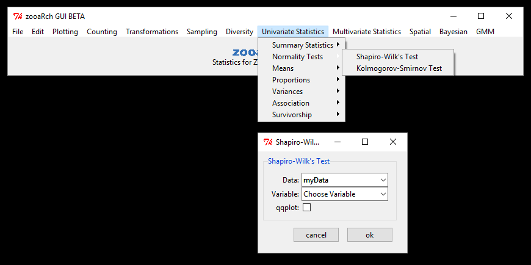

This function will perform a Shapiro-Wilk’s test on the selected dataset. It will accept dataframes either already in R memory or loaded by the user. The variable from the dataset that the test will be performed on is chosen in the “Variable” combobox. The results will be plotted if the “qqplot” checkbox is marked. The results will be saved in R memory as “Results”.

##### Kolmogorov-Smironov Test

[figure not shown]

This function will perform a Kolmogorov-Smirov test on the selected dataset. It will accept dataframes either already in R memory or loaded by the user. The variable from the dataset that the test will be performed on is chosen in the “Variable” combobox. An edcf plot will be created if the “edcf plot” checkbox is marked. The results will be saved in R memory as “Results”.

#### 8.3 Means

##### One Sample T-Test

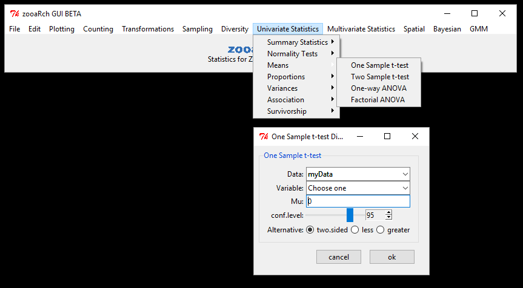

This function will perform a t-test on one sample. It will accept dataframes either already in R memory or loaded by the user. The variable from the dataset is chosen in the “Variable” combobox. The Mu value is inputted by the user along with the conf.level. The Alternative can be chosen to be either two-sided, less than, or greater than. The result are printed into the console and saved in R memory as “Results”.

##### Two Sample T-Test

[figure not shown]

This function will perform a t-test on two samples. It will accept dataframes either already in R memory or loaded by the user. The two variables for the test are chosen in their respective comboboxes. The conf.level is decided with the slider. The alternative can either be two-sided, less than, or greater than. The variables can be equal and/or paired if the checkboxes “var.equal” and “paired” respectively are marked. The results are printed into the consoles and saved in R memory as “Results”.

##### One-Way ANOVA

[figure not shown]

This function will perform a one-way ANOVA test on the selected dataset. It will accept dataframes either already in R memory or loaded by the user. The response variable is chosen using the “Response” combobox. The predictor variable is selected using the “Variable 1” combobox. The results can be plotted if the “plot” checkbox is marked. The results of the test are saved in R memory as “Results”. The results and summary are also printed into the console.

##### Factorial ANOVA

[figure not shown]

This function will perform a factorial ANOVA test on the selected dataset. It will accept dataframes either already in R memory or loaded by the user. The response variable is chosen using the “Response” combobox. The first and second variables are selected using the “Variable 1” and “Variable 2” respectively. The interaction between the two variables can be either multiplication or addition depending on the input in the “interaction” combobox. The results will be saved in R memory as “Results”. The results and summary are printed to the console. The result can be plotted if the “plot” checkbox is marked.

#### 8.4 Proportions

##### Chi Squared (row-by-column tests)

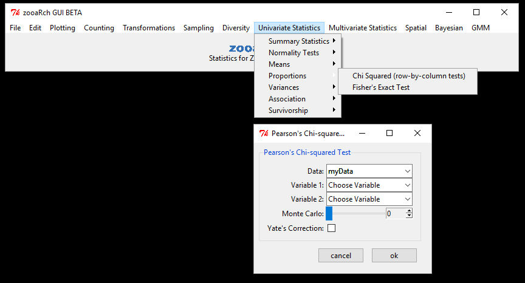

This function will perform the Chi Squared row-by-column test on the selected dataset. It will accept dataframes either already in R memory or loaded by the user. The first and second variable for the test *must be categorical* and can be selected in the “Variable 1” and “Variable 2” comboboxes respectively. The Monte Carlo value is selected using the slider, if a permutation test is desired. A Yate’s Correction will be performed during the test if the “Yate’s Correction” is marked. The results are saved to the R memory as “Results”. The results are also printed in the console. Use *data(“ClarksonLimbLoc”)* for an example, or choose appropriate categorical vaiables from *data(LRBdata)*.

##### Fisher’s Exact Test

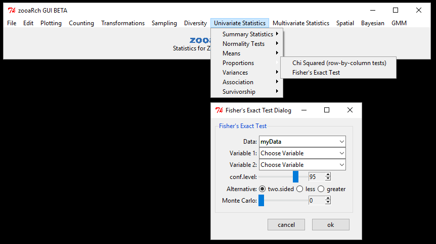

#### 8.5 Variances

##### F-Test

[figure not shown]

##### Bartlett’s Test

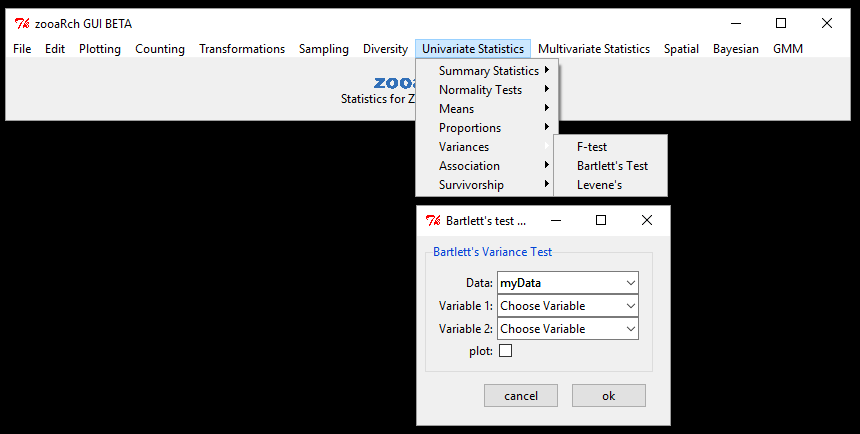

This function will perform a Bartlett’s Variance test on the selected dataset. It will accept dataframes either already in R memory or loaded by the user. The first and second variables for the test will be selected in the “Variable 1” and “Variable 2” comboboxes respectively. The results can be plotted if the “plot” checkbox is marked. The results are printed onto the console and saved in R memory as “Results”.

##### Levene’s

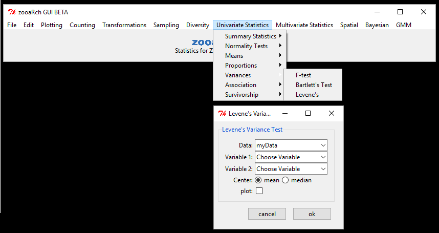

This function will perform a Levene’s Variance test on the selected dataset. It will accept dataframes either already in R memory or loaded by the user. The first and second variables for the test will be selected in the “Variable 1” and “Variable 2” comboboxes respectively. The center can either be the median of the data or the mean of the data. The results can be plotted if the “plot” checkbox is marked. The results are printed in the console and saved in R memory as “Results”.

#### 8.6 Association

##### Correlation

[figure not shown]

This function will perform an Association test on the selected dataset. It will accept dataframes either already in R memory or loaded by the user. The first and second variables for the test will be selected in the “Variable 1” and “Variable 2” comboboxes respectively. The conf.level will be selected using the conf.level slider. The alternative can either be tow sided, less than, or greater than. The Pearson’s r, Kendall’s tau, Spearman’s rho, and the Covariance can be calculated if their respective checkboxes are marked. If calculated they will be saved in R memory as “Pearson_Results”, “Kendall_Results”, “Spearman_Results”, and “Covariance_Results” respectively. The results can be plotted if the “plot” checkbox is marked.

##### Simple Linear Regression

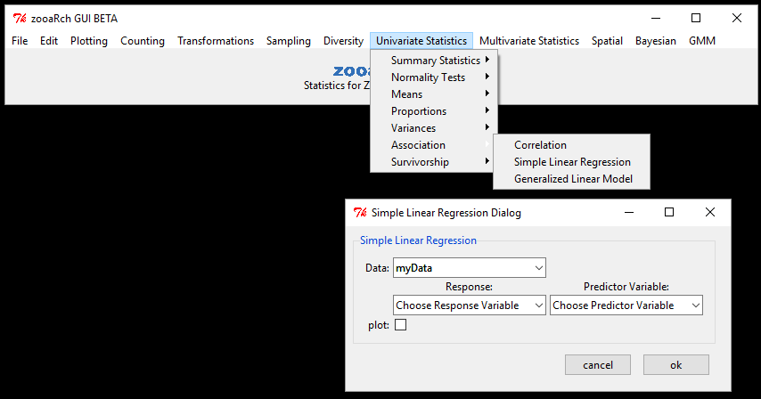

This function will perform a simple linear regression on the selected dataset. It will accept dataframes either already in R memory or loaded by the user. The response variable and the predictor variable are chosen using the “Response” and “Predictor” comboboxes respectively. The results can be plotted if the “plot” checkbox is marked. The results are printed in the console.

##### Generalized Linear Model

[figure not shown]

This function will create a generalized linear model of the selected dataset. It will accept dataframes either already in R memory or loaded by the user. The response variable is selected using the “Response” combobox. The first and second variable are selected using the “Variable 1” and “Variable 2” comboboxes respectively. The interaction between the variables can either be multiplication or addition depending on the selection in the interaction chosen in the “interaction” combobox. The distribution is determined by the “Distribution” combobox. The distribution can be either gaussian, binomial, poisson, or gamma. The variables can be linked either by identity, logit, log, or inverse. The results can be plotted if the “plot” checkbox is marked. The results are printed in the console and saved in R memory as “Results”.

#### 8.7 Survivorship

##### Survivorship

[figure not shown]

This function is will determine the survivorship of the dataset. It will accept dataframes either already in R memory or loaded by the user. The labels can be chosen using the “Labels” combobox to determine the dataset that the labels come from. The dataset that the model will come from is chosen using the “Model” combobox. The conf.level is selected using the conf.level slider. The functions that can be used are either the survivorship, Mortality, or Epophyseal Fusion functions. The number of iterations that the functions are run is determined by the “Iterations” spinbox. The results are printed in the console and saved in R memory as “Results”.